# Презентация по лабораторной работе №5

Построение графиков

Люпп Софья Романовна

1132236039@rudn.ru

Российский университет дружбы народов

2026-11-05

# Информация

## Докладчик

- Люпп Софья Романовна
- студентка группы НКНбд-01-23
- кафедра теории вероятностей и кибербезопасности
- Российский университет дружбы народов им. П. Лумумбы
- [1132236039@rudn.ru]
- https://github.com/srluipp

# Вводная часть

## Актуальность

Julia актуальна как инструмент для научных вычислений, финансового моделирования, искусственного интеллекта, вычислений в области инженерии и физики, благодаря своей высокой производительности, простоте синтаксиса и гибкости в работе с массивами и параллельным программированием

## Объект и предмет исследования

Язык программирования Julia и среда JupyterLab

## Цели и задачи

Основная цель работы — освоить синтаксис языка Julia для построения графиков.

# Выполнение лабораторной работы

Начинаю работу с воспроизведения результатов примеров из задания 5.2. Предварительно добавляю в Julia пакеты (рис. 1) (рис. 2).

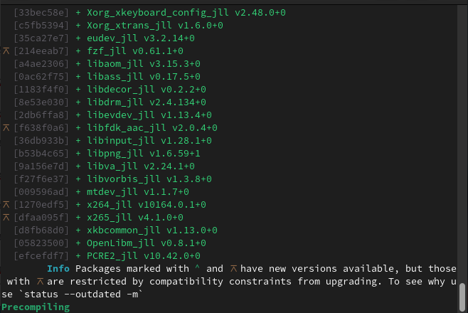

Рисунок 1: Установка пакетов

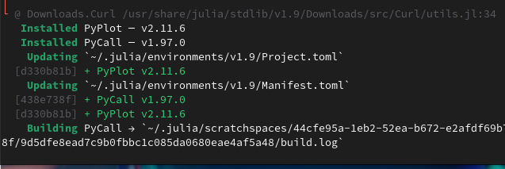

Рисунок 2: Установка пакетов

## Задания лабораторной работы

Выполняю пример 1 (рис. 3)

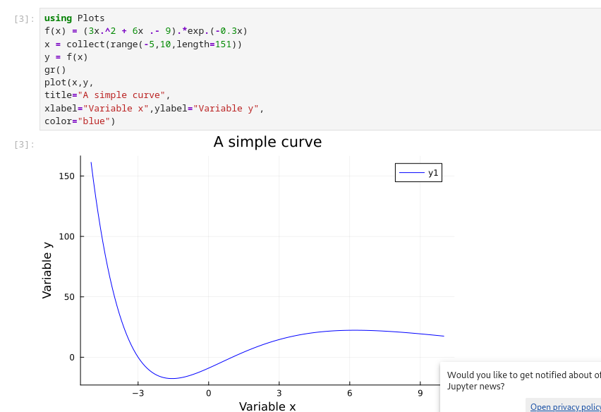

Рисунок 3: №1

## Задания лабораторной работы

Пример №2 разложение в ряд Тейлора (рис. 4)

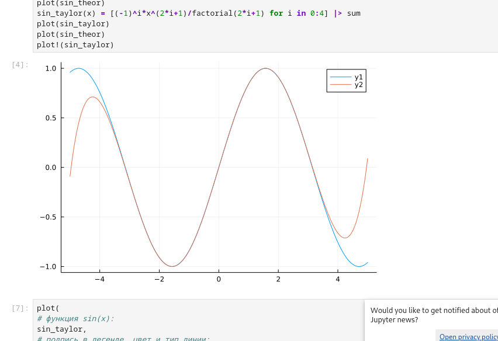

Рисунок 4: №2

## Задания лабораторной работы

Пример №3 - точечный график (рис. 5).

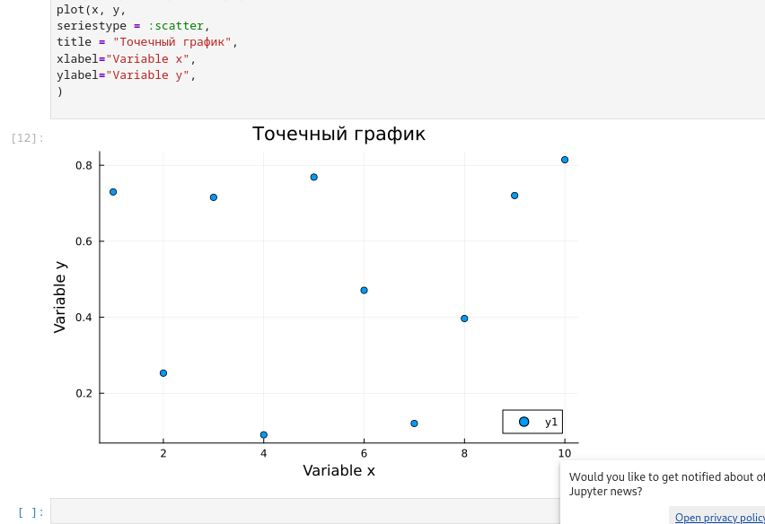

Рисунок 5: №3

## Задания лабораторной работы

Точечный график с кодированием значения размером точки (рис. 6)

[figure not shown]

Рисунок 6: №4

## Задания лабораторной работы

[figure not shown]

Рисунок 7: №5

## Задания лабораторной работы

Две оси ординат (рис. 8).

[figure not shown]

Рисунок 8: №6

## Задания лабораторной работы

Добавление на график второй случайной траектории(рис. 9).

[figure not shown]

Рисунок 9: №7

## Задания лабораторной работы

Пример построения графика функции в полярных координатах (рис. 10) .

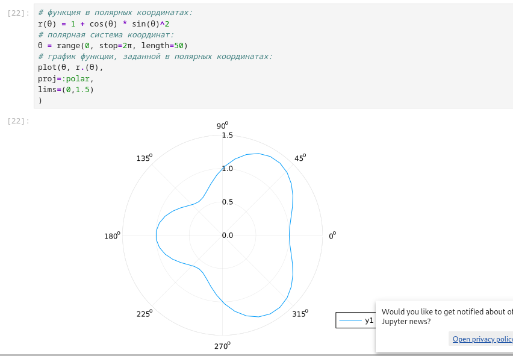

Рисунок 10: №8

## Задания лабораторной работы

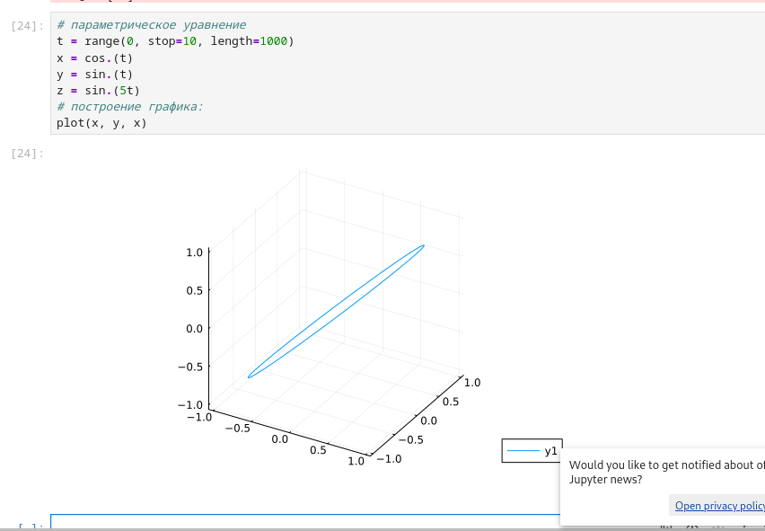

Рисунок 11: №8

## Задания лабораторной работы

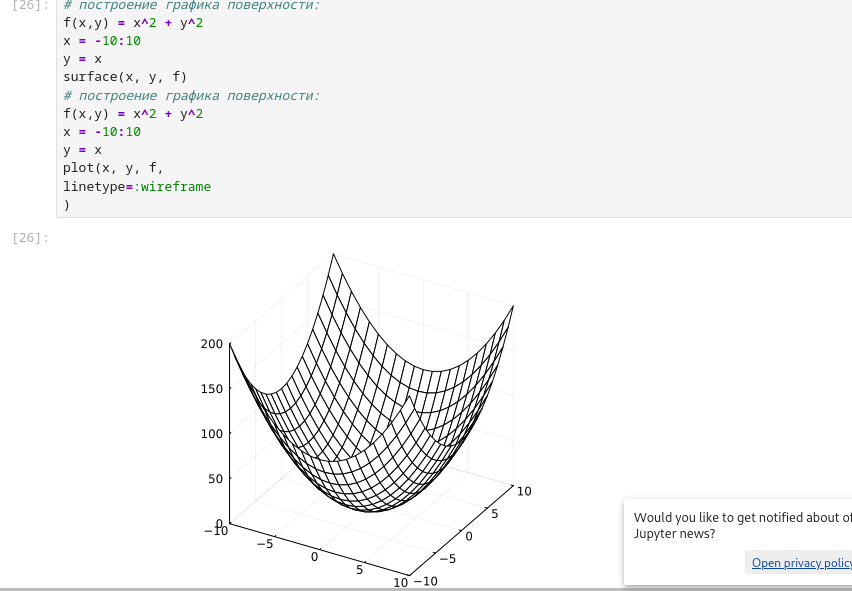

Рисунок 12: №8

## Задания лабораторной работы

График поверхности (рис. 13).

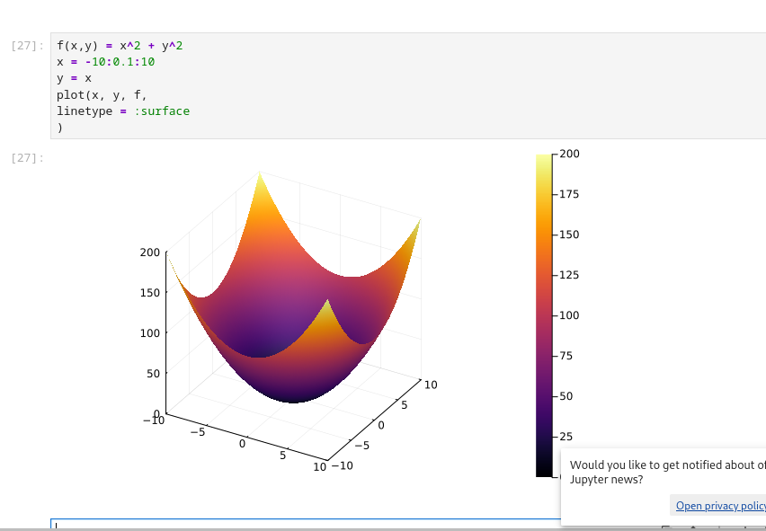

Рисунок 13: №7

## Задания лабораторной работы

График поверхности с измененным углом зрения (рис. 14)

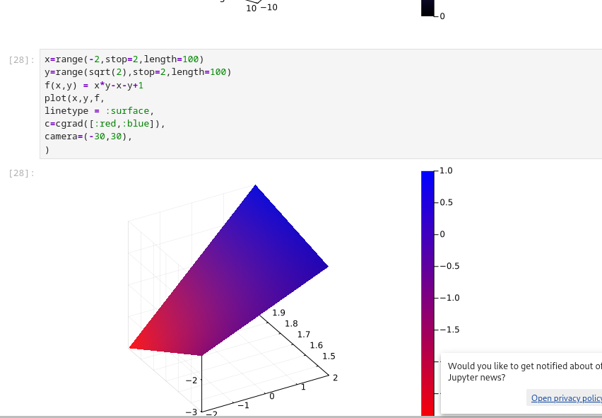

Рисунок 14: Угол зрения изменен

## Задания лабораторной работы

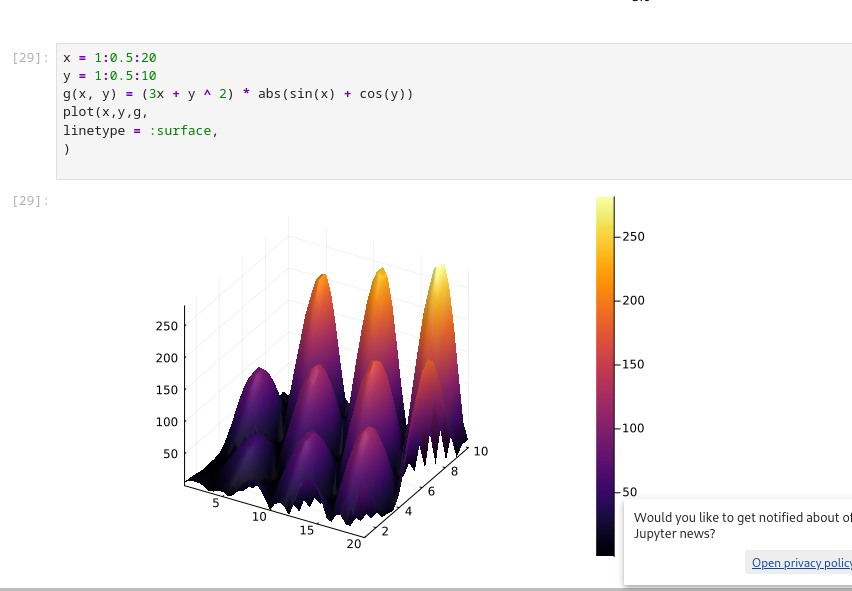

## Задания лабораторной работы

Линии уровня (контур)(рис. 16)

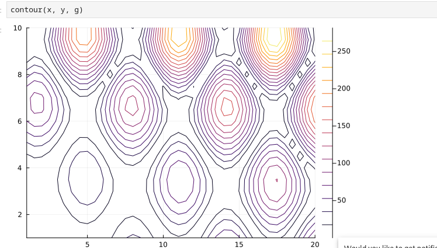

Рисунок 16: контур

## Задания лабораторной работы

Линии уровня с заполнением (рис. 17)

[figure not shown]

Рисунок 17: С заполнением

## Задания лабораторной работы

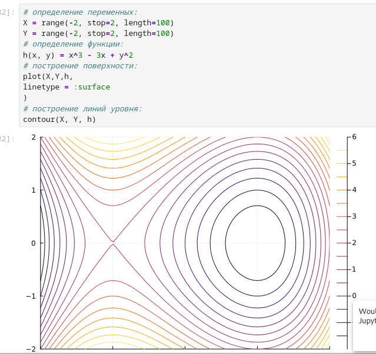

## Задания лабораторной работы

Гипоциклоида (рис. 19)

[figure not shown]

Рисунок 19: Гипоциклоида

## Задания лабораторной работы

Анимация гипоциклоиды (рис. 20)

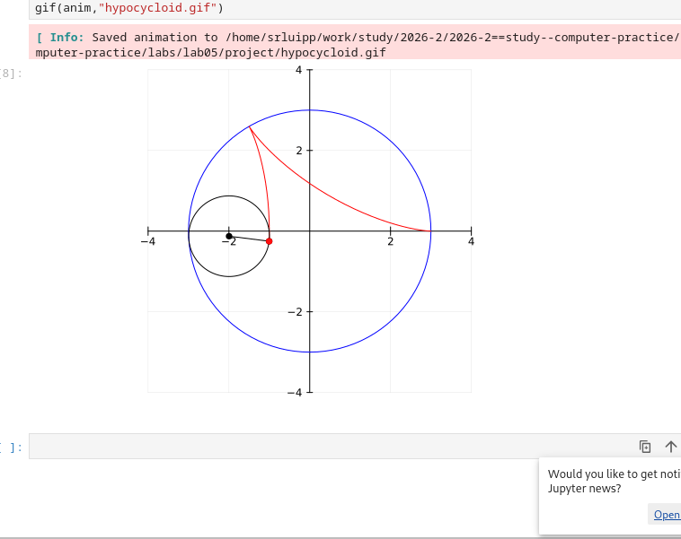

Рисунок 20: Анимация гипоциклоиды

## Задания лабораторной работы

График погрешности измерения Errorbars (рис. 21)

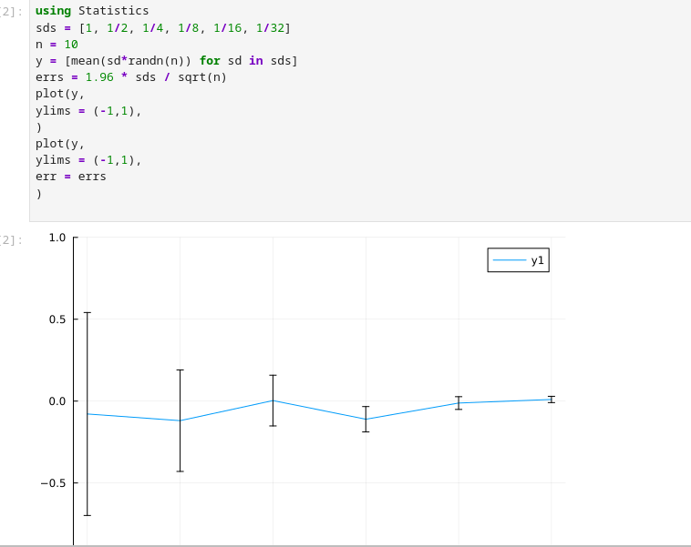

Рисунок 21: Errorbars

## Задания лабораторной работы

Заполнение графика цветом (рис. 22).

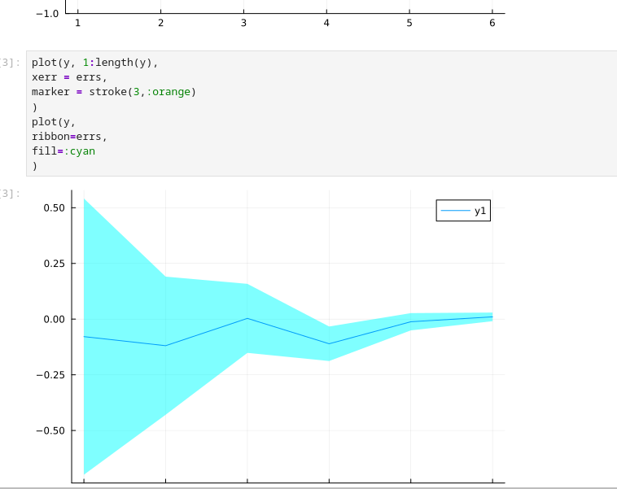

Рисунок 22: Заполнение цветом

## Задания лабораторной работы

График ошибок по двум осям (рис. 23) (рис. 24)

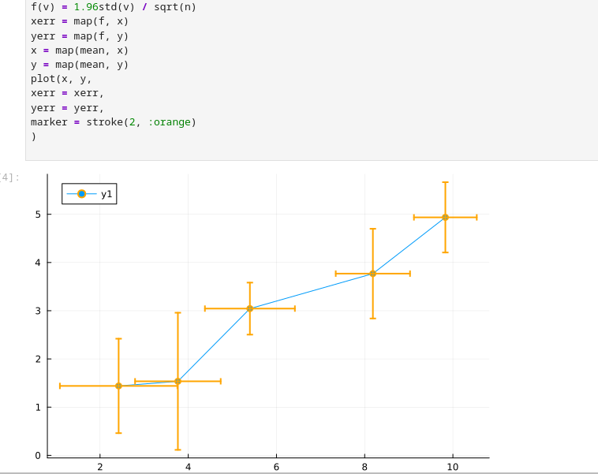

Рисунок 23: График ошибок по двум осям

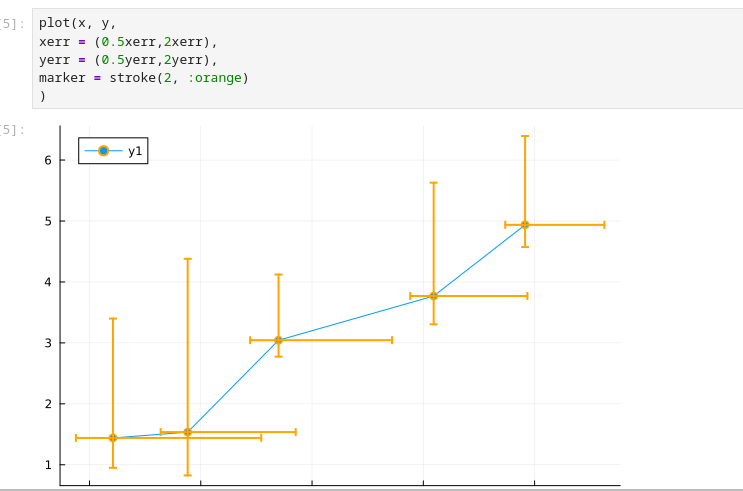

Рисунок 24: График ошибок по двум осям

## Задания лабораторной работы

Устанавливаю необходимые пакеты для статистики (рис. 25) .

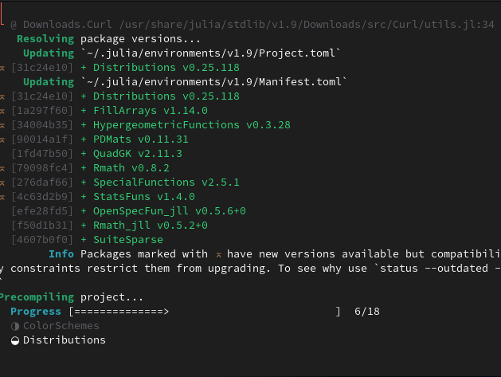

Рисунок 25: Пакеты

## Задания лабораторной работы

Гистограмма, построенная по массиву случайных чисел (рис. 26) .

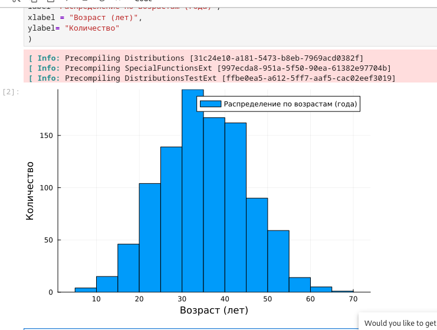

Рисунок 26: Гистограмма

## Задания лабораторной работы

Гистограмма распределения людей по возрастам (рис. 27).

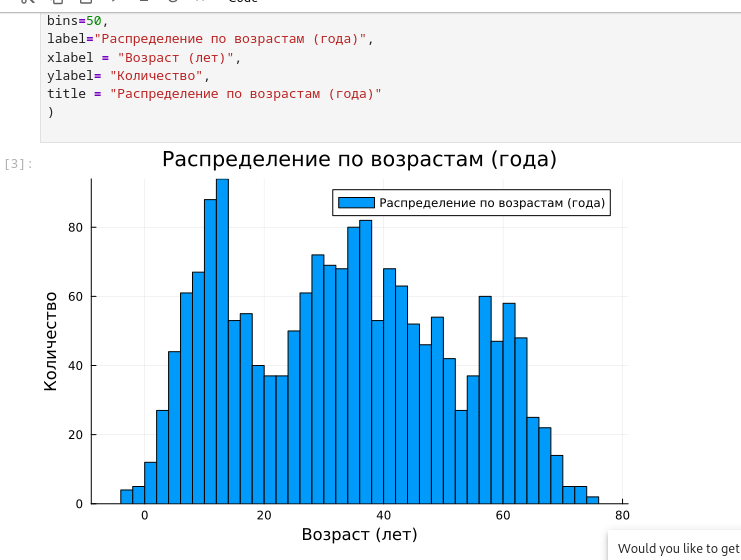

Рисунок 27: Гистограмма

## Задания лабораторной работы

Серия из 4-х графиков в ряд (рис. 28).

[figure not shown]

Рисунок 28: Подграфики

## Задания лабораторной работы

Обьединение графиков в одной сетке (рис. 29).

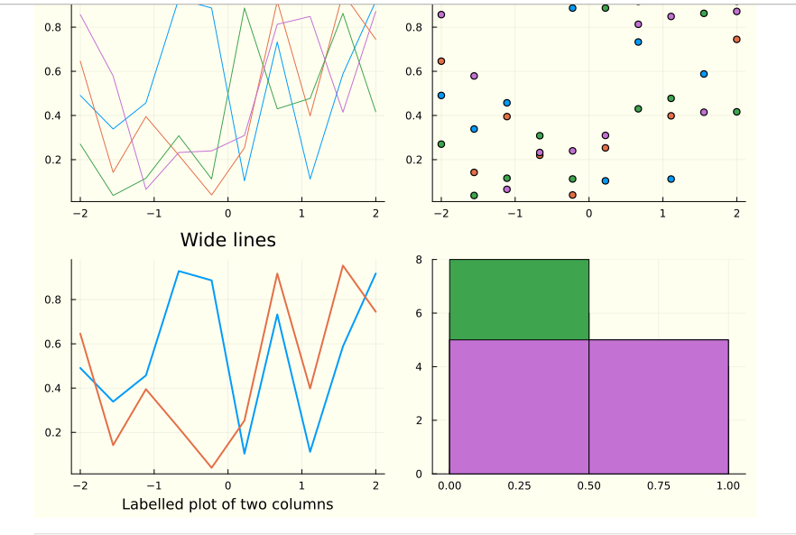

Рисунок 29: Подграфики